# act_report

[figure not shown]

## Analysis

After the data wrangling process, i was able to clean up the data and store the clean data in a my local computer as a csv file named "Twitter_archive_master.csv". This data was futher imported and used in conducting analysis where the following insights were discovered and proper visualisations was created to back each insights.

### Insights:

1. Doggo have Higher favorite counts compared to other dogs stages
2. The algorithm of prediction is more confident on P1_dogs predictions compared to P2 and P3 dogs predictions
3. There is positive correlation between favorite counts and retweet counts
4. Pupper dogs have the highest valid ratings compared to other dog stages
5. The Dogs with the mean highest ratings appears to be the Doggos and not the Puppers

   For the first insight i observed that doggos appeared to accumulate more favorite counts compared to other dogs.This is properly illustrated using the visuals below

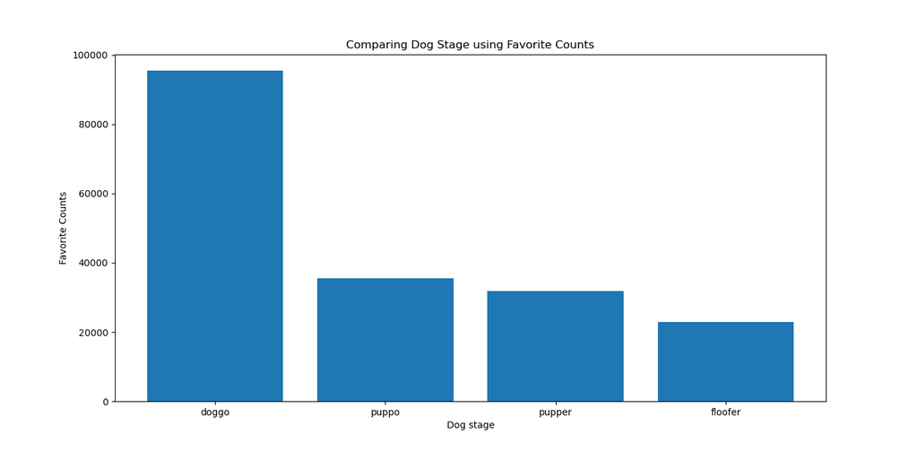

For the Second insight it appeared that the confidence levels are higher for the p1_dogs predictions compared to any other predictions in the dataset.This is illustrated in the diagram below.

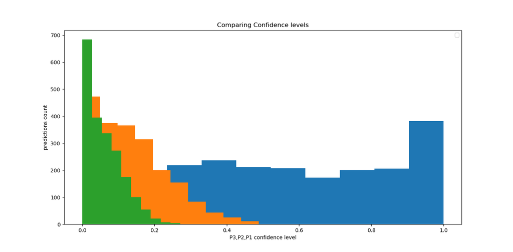

For the Third insight, I observed the existence of a strong positive correlation between retweet counts and favorite counts in the data set, This is further illustrated in the diagram below.

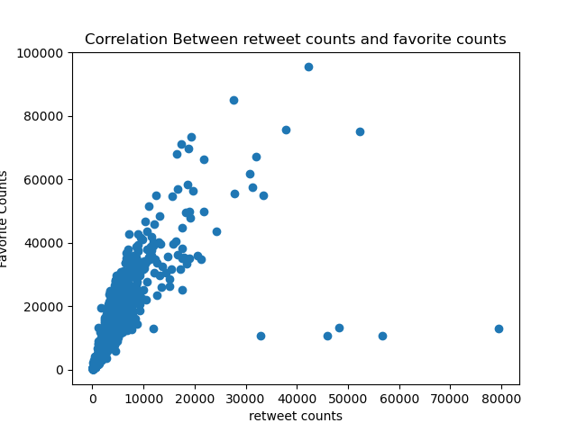

From the Scatterplot above we can observe the upward trend in the data points relating favorite counts and retweet counts, which is a good indicator of a positive correlation between these two variables.

Futhermore, The Correlation table below gives the exact correlation coefficient between favorite count and Retweet count

```python
CORRELATION TABLE
```

|  | tweet_id | rating_numerator | rating_denominator | img_num | first_confidence_level | is_first_prediction_a_dog | second_confidence_level | is_second_prediction_a_dog | third_confidence_level | is_third_prediction_a_dog | favorite_count | retweet_count | ratings |
| --- | --- | --- | --- | --- | --- | --- | --- | --- | --- | --- | --- | --- | --- |
| tweet_id | 1.000000 | 0.022101 | -0.026534 | 0.210551 | 0.117311 | 0.128051 | -0.001562 | 0.130931 | -0.050717 | 0.100689 | 0.700017 | 0.397183 | 0.026963 |
| rating_numerator | 0.022101 | 1.000000 | 0.167981 | -0.000668 | -0.008605 | -0.027133 | -0.019472 | -0.032875 | -0.002983 | -0.027815 | 0.010335 | 0.013714 | 0.985440 |
| rating_denominator | -0.026534 | 0.167981 | 1.000000 | 0.000270 | -0.001117 | 0.021034 | -0.033878 | 0.019931 | 0.011983 | 0.024558 | -0.030519 | -0.020964 | -0.001714 |
| img_num | 0.210551 | -0.000668 | 0.000270 | 1.000000 | 0.212560 | 0.037093 | -0.157672 | 0.057609 | -0.143512 | 0.065934 | 0.153900 | 0.104415 | -0.000937 |
| first_confidence_level | 0.117311 | -0.008605 | -0.001117 | 0.212560 | 1.000000 | 0.128704 | -0.511323 | 0.143421 | -0.710881 | 0.120545 | 0.108314 | 0.064821 | -0.008670 |
| is_first_prediction_a_dog | 0.128051 | -0.027133 | 0.021034 | 0.037093 | 0.128704 | 1.000000 | 0.109230 | 0.632023 | 0.051301 | 0.563619 | 0.057493 | 0.017171 | -0.030675 |
| second_confidence_level | -0.001562 | -0.019472 | -0.033878 | -0.157672 | -0.511323 | 0.109230 | 1.000000 | 0.093568 | 0.477365 | 0.067598 | -0.022778 | -0.022791 | -0.013911 |
| is_second_prediction_a_dog | 0.130931 | -0.032875 | 0.019931 | 0.057609 | 0.143421 | 0.632023 | 0.093568 | 1.000000 | 0.037485 | 0.548312 | 0.075841 | 0.023732 | -0.036308 |
| third_confidence_level | -0.050717 | -0.002983 | 0.011983 | -0.143512 | -0.710881 | 0.051301 | 0.477365 | 0.037485 | 1.000000 | 0.036478 | -0.062991 | -0.049119 | -0.004765 |
| is_third_prediction_a_dog | 0.100689 | -0.027815 | 0.024558 | 0.065934 | 0.120545 | 0.563619 | 0.067598 | 0.548312 | 0.036478 | 1.000000 | 0.042411 | 0.019860 | -0.032284 |
| favorite_count | 0.700017 | 0.010335 | -0.030519 | 0.153900 | 0.108314 | 0.057493 | -0.022778 | 0.075841 | -0.062991 | 0.042411 | 1.000000 | 0.749414 | 0.015542 |
| retweet_count | 0.397183 | 0.013714 | -0.020964 | 0.104415 | 0.064821 | 0.017171 | -0.022791 | 0.023732 | -0.049119 | 0.019860 | 0.749414 | 1.000000 | 0.017381 |
| ratings | 0.026963 | 0.985440 | -0.001714 | -0.000937 | -0.008670 | -0.030675 | -0.013911 | -0.036308 | -0.004765 | -0.032284 | 0.015542 | 0.017381 | 1.000000 |

The correlation table shows that the correlation coefficient between retweet count and favorite count is (0.75) which is a high positive correlation coefficient.

lastly, i observered that pupper dogs have the highest valid ratings compared to other dogs stages, this is illustrated below with the following visuals

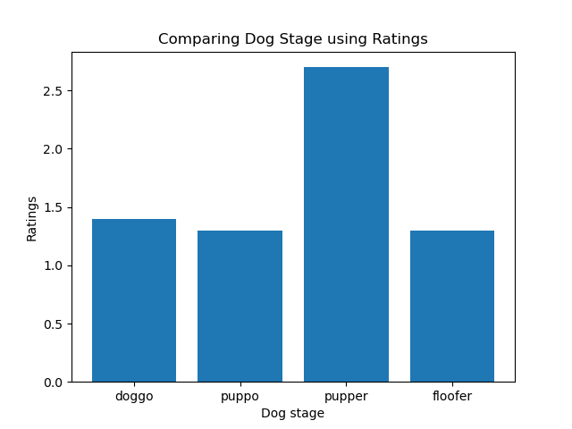

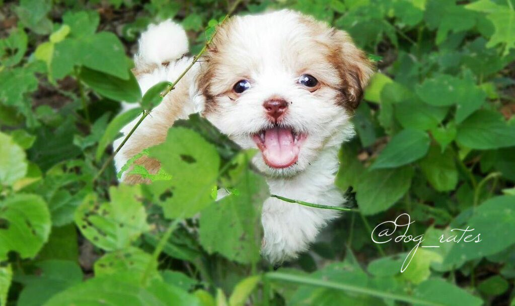

Meet Sophie the pupper with Highest valid rating, isnt she cute....... she had a 27/10 .......i think she deserve it, what do you think??

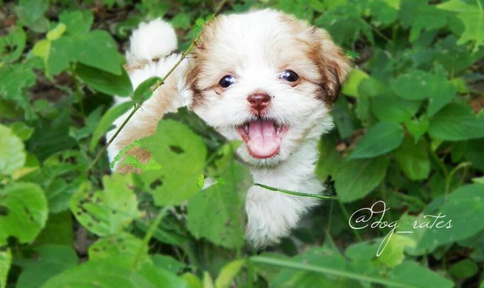

https://twitter.com/dog_rates/status/778027034220126208/photo/1 ..........and is a link to her tweet.....you can feel free to check it up

although the pupper has the highest rating, it appears the dog stage with the highest mean rating is the doggo with a mean rating of 1.2 approx.

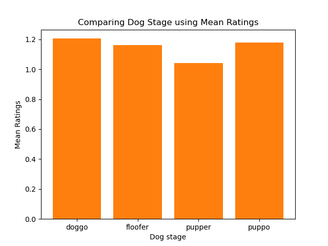

Thanks for reading....................................................